# 項目反応理論の基礎

ー試験と臨床での測定と項目運用ー

国里愛彦(専修大学)

2025-08-04

## 本日のスライド

[figure not shown]

## 自己紹介

### 国里 愛彦（くにさと よしひこ）

- 専修大学人間科学部心理学科 教授
- 心理学出身、博士は広島大学精神科で取得
- 専門は計算論的精神医学や認知行動療法。心理統計を含む研究の方法論を学ぶのは好きだが、テスト理論の専門家ではない
- 金沢医科大学一般教育機構の佐々木美保准教授と大学院の同期生
- 金沢に初めてきました

## そもそもテストとは？

- 古くは中国の科挙
- 身近なところでは、大学入試や国試など

→大学入試や国試の場合は、試験問題が公開されており（過去問集など）、その都度新規に試験問題を作成している(「項目使い捨て主義」)。

→専門家による難易度の検討はあるものの、毎年同じ難易度かは確実ではない。

## 医師国家試験におけるCBTの活用

- 医師国家試験におけるCBT（computer-based testing）の活用が議論されている。
- CBTの背景には項目反応理論（item response theory、以下IRT）がある。
- IRTは患者さんから報告されるアウトカム（患者報告式アウトカム）での活用もなされており、医学に関係の深いテスト理論

## 古典的テスト理論

- IRTは古典的テスト理論(classical test theory)の限界を補うために出てきた。
- 古典的テスト理論では、テストを行って得られる得点は以下のように考える。

テスト得点＝真の得点＋測定誤差

- 真の得点（テストで測りたい能力の値）をちゃんと測定するには、測定誤差を小さくする必要がある。

## 古典テスト理論での信頼性

- 古典的テスト理論では以下のように信頼性を定義

$$信頼性=\frac{真の得点の分散}{テスト得点の分散}$$

- 真の得点が変化していない場合、繰り返しテストを実施した平均が真の得点、平均からのズレが測定誤差

→繰り返し測定におけるブレの小ささが信頼性の指標

## 古典的テスト理論での信頼性の指標

- 再テスト法：テストを繰り返し実施して、その相関係数を信頼性係数とする。
- 折半法：テストを半分に分けて、２つのテスト得点の相関係数を信頼性係数とする。
- クロンバックの$\alpha$係数：テストの内的一貫性を示す指標であり、信頼性係数の下界を示す。

→全ての指標が、テストにつき１つの値を出力する。

## 古典テスト理論での評価指標：項目困難度と項目識別力

- 項目困難度：テストの項目に対する正答率。正答率が高いほど易しい項目になる。
- 項目識別力：テスト全体得点と項目得点との点双列相関係数（連続的なテスト全体の得点と２値の項目得点の相関）。識別力が高いほど、テスト全体で測ろうとしているものを反映できている。

→項目困難度も項目識別力も直感的に理解ができ、テスト作成の実務ではよく使われる。

## 古典的テスト理論の限界

- 項目困難度や項目識別力といった指標は、受験者集団に依存して相対的に決定される（標本依存性）

→受験者の能力が高いと項目困難度は下がる。受験者の能力のばらつきが小さいと識別力が低くなる。誰にテストをするかで項目の評価が変わる。

- テスト得点がテスト項目に依存する （項目依存性）

→項目困難度の低い（正答率の高い）項目ばかりで構成されたテストはテスト得点が高くなる。どういう項目で測定するかでテスト得点の評価が変わる。

## 項目反応理論とは

- 古典的テスト理論では、標本依存性（項目の評価がサンプルに依存する）と項目依存性（テスト得点の評価が項目に依存する）の問題がある。

→古典的テスト理論の限界を克服するため、IRTが発展してきた。

→IRTならば、受験者の能力パラメタ（$\theta$）と項目の特徴を表す項目パラメタ（困難度、識別力）を別々に評価できる。

## 項目反応理論のモデル：１パラメタ・ロジスティックモデル

- （正誤の２値データの場合）IRTはロジスティックモデルを用いる。最もパラメタ数が少ないのが１PLM(one parameter logistic model)である。

$$P_j(\theta) = \frac{1}{1 + \exp(-Da(\theta - b_j))}$$

ラッシュモデルとも呼ぶ（数学的には一緒だが、ラッシュモデルはモデルありきであり、スタンスが違う）

## １PLMのパラメタ

$$P_j(\theta) = \frac{1}{1 + \exp(-Da(\theta - b_j))}$$

- $\theta$は受験者の能力であり、$P_{j}(\theta)$はある$\theta$における正答確率($j$は項目番号を意味する)
- 関心のあるパラメタは$b$であり、項目の困難度
- $D$は尺度因子と呼ばれ、一般的に1.7を指定。$a$は全ての項目で共通する識別力、$a$も推定されるが項目ごとの特徴を表すものではない。

## 項目特性曲線

- 項目特性曲線(item characteristic curve:ICC)は、横軸に受験者の能力$\theta$、縦軸に各項目の正答確率をプロットしたもの。

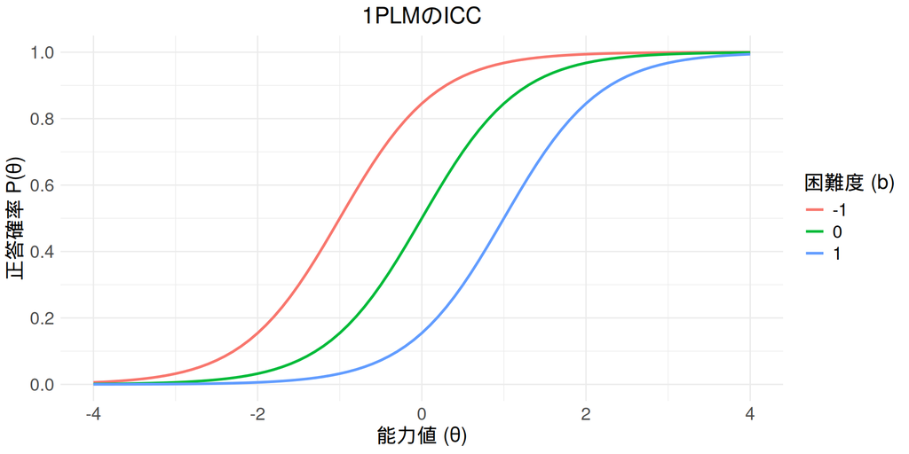

## １PLMのICC

- 困難度が大きいほど$\theta = 0$の正答確率は下がる(曲線の形は一緒だが位置がズレるモデル)

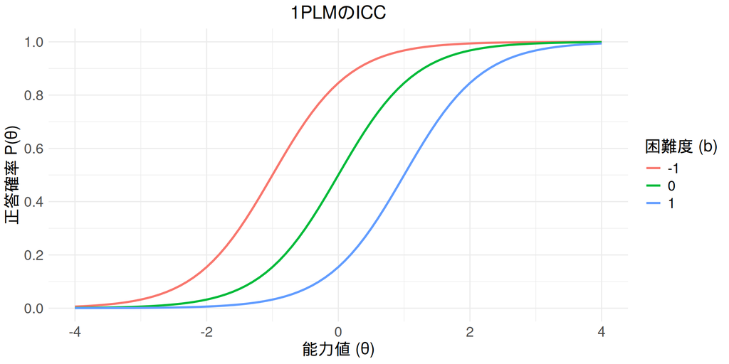

## 項目反応理論のモデル：２パラメタ・ロジスティックモデル

$$P_j(\theta) = \frac{1}{1 + \exp(-Da_{j}(\theta - b_j))}$$

- 2PLM(two parameter logistic model)は、1PLMの項目に共通する識別力$a$が$a_{j}$ のように添え字$j$がついて、項目ごとに推定される
- 2PLMは、各項目の困難度と識別力から項目の特徴を明らかにする。

## 2PLMのICC

- 困難度は同じ、識別力だけ変えたプロット。識別力が高いほど曲線の傾きが急になり、傾きが急なほど受験者の能力に合わせて正答率が変わる。

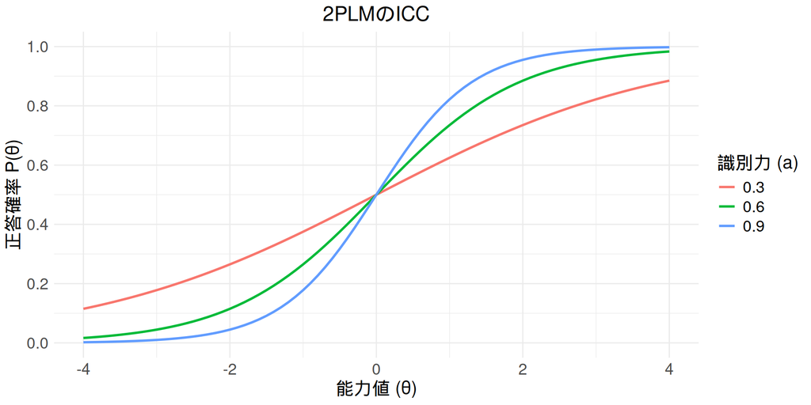

## 項目反応理論のモデル：３パラメタ・ロジスティックモデル

- 3PLM(three parameter logistic model)は、困難度と識別力に加えて、当て推量パラメタ$c$が追加される。

$$P_j(\theta) = c_{j} + (1-c_{j})\frac{1}{1 + \exp(-Da(\theta - b_j))}$$

## 項目反応理論のモデル：３PLM

- 多肢選択式の問題は、正答がわからない時でも適当に選べば正答することがある。このような偶然正答するような可能性をモデル化している。
- ある項目の正答確率の一部は、当て推量$c_{j}$によって説明でき、残りを２PLMで説明するモデルである

$$P_j(\theta) = c_{j} + (1-c_{j})\frac{1}{1 + \exp(-Da(\theta - b_j))}$$

## 3PLMのICC

- 当て推量$c$が大きいほど、正答確率がカサ増しされる。3PLMと2PLMでは識別力と困難度の解釈は変わってしまうので注意が必要

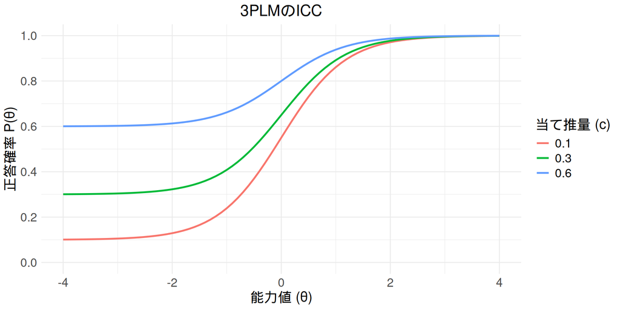

## 項目情報関数とテスト情報関数

- 古典的テスト理論では、信頼性の指標はテスト全体で１つであり（クロンバックの$\alpha$係数など）、受験者の能力のレベルに対応したものではない。
- IRTでは、受験者の能力のレベルに応じた測定精度の指標がある。
- IRTでの測定精度の指標としては、項目に対する項目情報関数(item information function:IIF)とテストに対するテスト情報関数(test information function:TIF)がある。IIFとTIFは受験者集団に依存しない値になる。

## 項目情報関数

- 受験者の能力$\theta$を横軸、各項目の情報量を縦軸にプロット

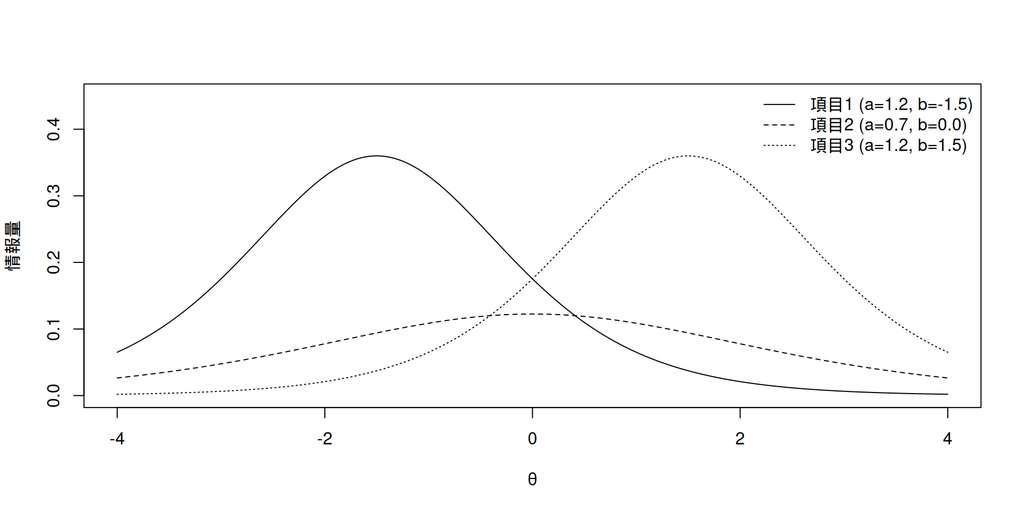

## 項目情報関数

- 困難度の値で情報量が最大になり、識別力が高いほど情報量が大きい

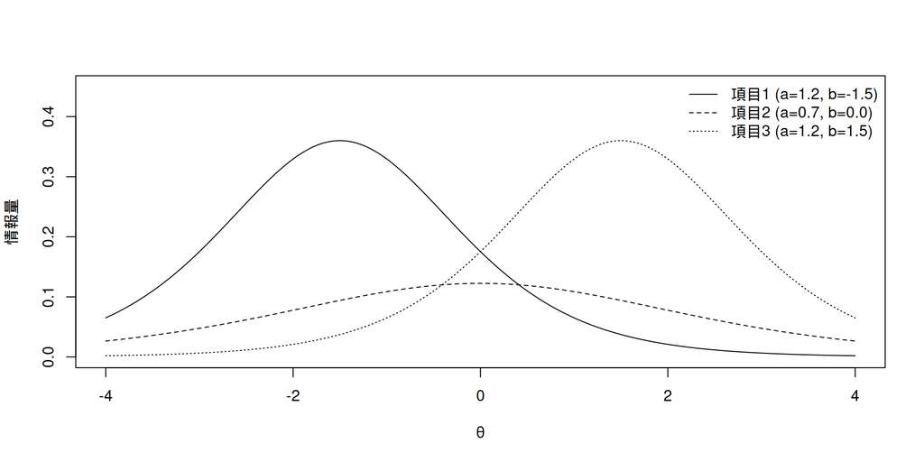

## テスト情報関数

- 受験者の能力$\theta$を横軸、テスト全体の情報量を縦軸にプロット（TIFはIIFの和）

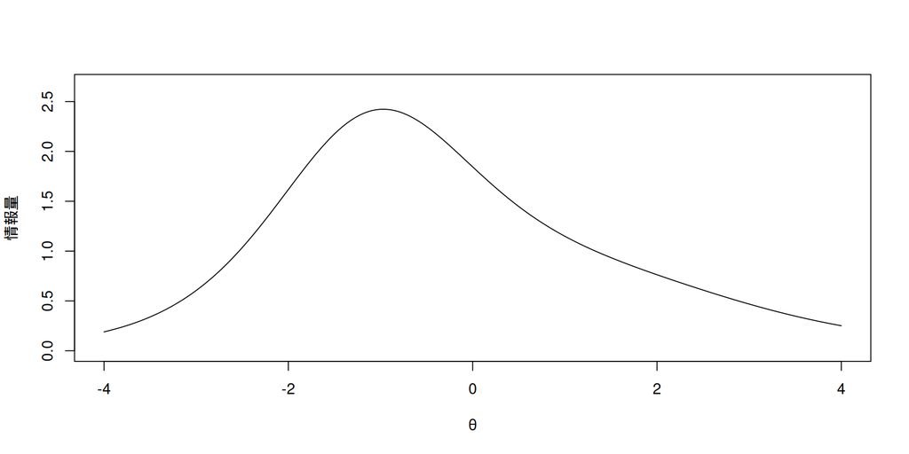

## テスト情報関数

- どの範囲の能力において精度の高い測定が可能かわかる（以下の図では-2から0の範囲で精度が高い）

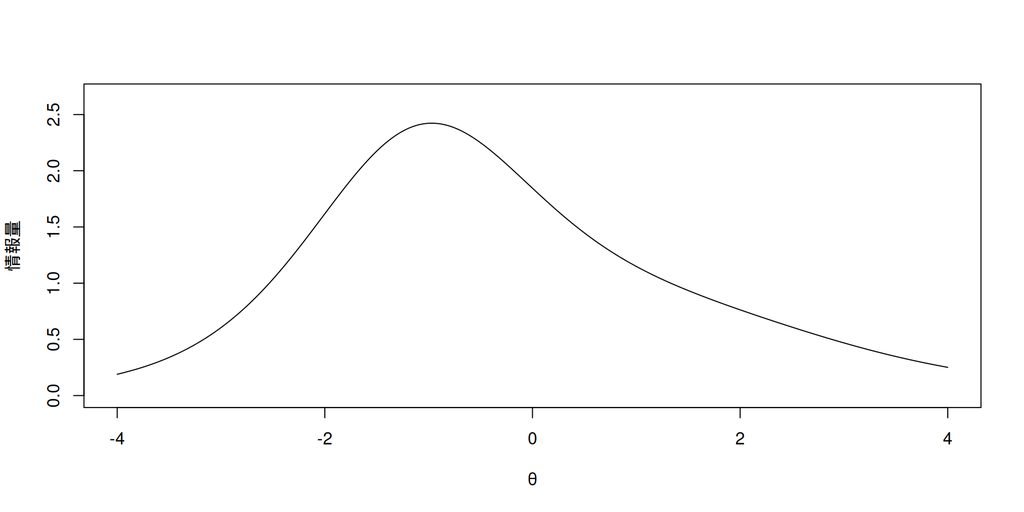

## 1PLM,2PLM,3PLMの比較（順位）

- 加藤・山田・川端(2014)を参考に整理

|  | 1PLM | 2PLM | 3PLM |
| --- | --- | --- | --- |
| 推定の正確度 | 2 | 1 | 3 |
| 計算時間の経済性 | 1 | 2 | 3 |
| サンプルサイズ(目安) | 100-200 | 200-400 | 1000-2000 |
| 得られる情報 | 3 | 2 | 1 |
| 解釈のしやすさ | 1 | 2 | 3 |

→1PLMは得られる情報は少ないが現実的な選択肢になる

## その他のIRTモデル

- テストは正誤の２値の反応データを扱うので、１〜３PLMを使うが、1から7までの７段階評定などの多値データの場合は１〜３PLMは適用できない。
- 多値データの場合は、段階反応モデル(graded response model: GRM)や部分得点モデル(partial credit model: PCM)などの多値型IRTモデルが使われる。

→小論文採点データへの適用、パーソナリティなどの心理検査などへの適用がある。

## 項目反応理論の前提

- IRTを用いるだけで標本依存性と項目依存性が自動的に解決されるわけでなく、そのための前提条件がある。
- 重要な仮定として、１次元性と局所独立性があり、これらを満たしている必要がある。
- データへのモデル適合度もIRTを解釈する上で必要になる。

## 項目反応理論の前提：一次元性

- 1〜３PLMは一次元性(unidimensionality)が仮定されている。
- １次元性とは、テストの項目群が１種類の能力を測定していることである（英語能力を測定しているのに、数学の能力が必要な項目が混ざってないか？）。
- 一次元性の確認は、因子分析を行なって、そのテストが１因子が妥当かどうかを確認する（なお、２値反応データの場合は、四分相関係数による相関行列を用いる）。

## 項目反応理論の前提：局所独立性

- IRTを用いる場合は、項目反応が局所独立(local independence)している必要がある（満たさないと推定が大変困難になる）。
- 局所独立性：能力$\theta$を固定したとき、各テスト項目への反応は互いに独立である

→能力が高い人は複数の項目の反応が正答する方向で相関するが、能力で統制した場合に、ある項目で正答するかは、他の項目で正答するかどうかの影響を受けないという意味。

## 局所独立性の阻害要因

1. 項目間の直接的な依存関係：問２を解くには問１が解けないといけないなど
2. 項目間の間接的な依存関係：ある文章や設定から複数の問題が出される場合に、その文章や設定を知っていると問題間に間接的な影響が生じる
3. 能力$\theta$以外の異なる特性の影響：測定したい能力以外の疲労や外的な要因などの影響が大きい場合

## 局所独立性の検討

- 局所独立性を脅かすようなケースがないか項目を質的に検討する
- $Q_{3}$統計量($\theta$で説明できない各項目の残差間の相関)を計算し、0.20を超えてないか判定する（相関が0.20を越えるペアは局所独立性が仮定しにくいと考える）。

## 項目反応理論の前提：適合度

- IRTの能力パラメタの推定には最尤推定法が使われ、項目パラメタの推定には周辺最尤推定法が使われる。
- IRTではデータからパラメタを推定するので、IRTモデルがデータにちゃんとフィットしていなければいけない。

→適合度を検討する(IRTでは個人適合度、項目適合度、全体適合度がある)

## 適合度の検討

- 個人適合度：受験者の反応が能力から予測できるものと一致しているか検討（$z3$統計量を計算し、$|z3|>1.96$になってないか検討）
- 項目適合度：個々の項目について推定されたICCがデータにどの程度当てはまるか検討($\chi ^2$統計量を計算し、有意でないか検討)
- 全体適合度：個々の受験者や項目ではなく、モデル全体のデータへの適合度を検討（尤度比カイ二乗統計量$G^2$を計算し、有意でないか検討）

## 等化

- ２つの尺度がある時に、どちらかの尺度に、もう一方の尺度の0の位置や目盛の幅を揃えることを等化(equating)と呼ぶ。
- IRTは標本依存性や項目依存性はないが、受験者集団の影響を受けないわけではないので推定された項目母数は異なる。等化によって、項目母数を片方の集団に揃えて表現できる。
- 等価によって異なる受験者集団の結果を比較することができるため（異なるテストの難易度を揃えることができる）、IRTを用いる大きなメリットとなる。

## 等化の考え方と等化係数

- 受験者集団AにテストAを実施し、受験者集団BにテストBを実施した場合、テストAとテストBが完全に異なると等化できないので、共通する項目を入れる。
- 共通項を使って、テストAの項目母数にテストBの項目母数を変換する場合に、以下の式で変換をする(等化係数の$K$と$L$を推定するために共通項目がいる)。

$$a_{jB}^* = \frac{a_{jB}}{K} , b_{jB}^* = Kb_{jB} + L$$

## 等化のデザイン

- 等化では２つのテストを繋ぐための情報を得るためにテストの実施計画を工夫する。
- 等化のデザインとしては、共通項目計画、共通受験者計画、係留テスト計画がある。
- 大量のテスト項目を扱う場合は、重複テスト分冊法もある。

## 共通項目計画

- ２つのテストに共通の問題項目を含めて等化する方法

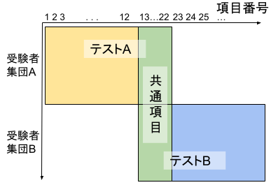

## 共通項目計画

- (1)共通項目の非公開が必須、(2)共通項目の数が多いほど等化の精度が上がるため、ある程度の共通項目を含められるテストである必要がある。

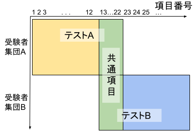

## 共通受験者計画

- ２つのテストをどちらも受験する共通受験者をおいて等化する方法

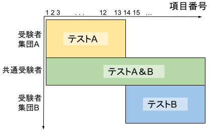

## 共通受験者計画

- 同時に受験が難しい場合にカウンターバランスも必要、２つのテストをどちらも受験する者を用意するのはコストがかかる。

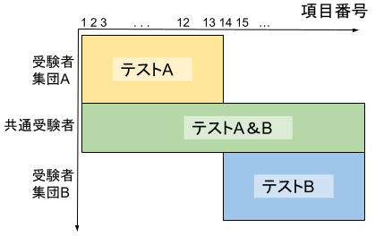

## 係留テスト計画

- 共通項目と共通受験者計画を組み合わせた方法。２つのテストをつなぐ別のテスト（係留テスト）をおいて共通受験者が受験する。

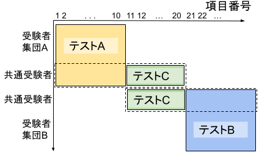

## 係留テスト計画

- 係留テスト（テストC）を非公開にして、テストAとテストBをテストCに等化すると、AとBの等価もできる。

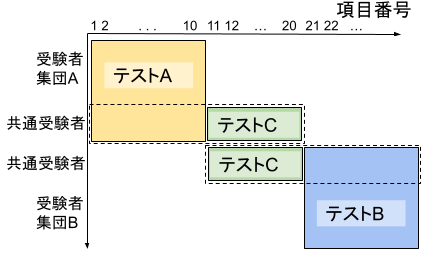

## 重複テスト分冊法

- 大量の項目がある場合に共通受験者計画は難しいので、テスト項目をブロックに小分けして、共通項目によって等化する方法

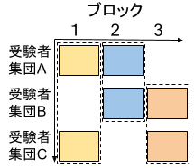

## 重複テスト分冊法

- 受験者集団間で共通項目(ブロック)ができるようにブロックを組み合わせて分冊を作る。
- ブロックの使用回数やブロックの組み合わせパターンを等しくし、分冊の中でブロックの順番を偏らないなどの工夫もある（釣合型不完備ブロックデザイン）

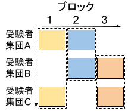

## 等化のデザインの留意事項

- 共通項目数、共通受験者数などのテストをつなぐ情報をできるだけ豊かにする必要がある（共通項目数や共通受験者数は多いほど精度が高くなる）。
- 共通項目数や共通受験者数などの決定はテストに依存するため、シミュレーションなどを行なって決定することになる。
- ただ、実施の実現可能性、必要となるコスト（時間、金など）などから現実的に決めることも必要になる。

## 等化係数の求め方

- Mean-Sigma法：困難度と能力を用いて等化
- Mean-Mean法：困難度と識別力と能力を用いて等化
- Haebara法: 項目特性曲線の差異を最小化して等化
- Stocking-Lord法: テスト特性曲線の差異を最小化して等化

## 等化の前提

1. 複数の分冊が同じ構成概念を測定している。
2. 等化の対称性（テストAを基準に等化しても、テストBを基準に等化しても同じ）
3. 複数の分冊の信頼性が等しい
4. 能力値が同じ人をそれぞれのテストから取り出した時の測定誤差が等しい
5. 等価の結果は集団によらず不変（集団ごとに行なった等化と全体で行なった等化が等しい）

## 項目バンク

- 共通尺度に等化された項目パラメタを持つ項目群を項目プールもしくは項目バンクと呼ぶ。
- 項目のデータベースを作っておけば、それをコンピュータ適応型テストで実施して、効率的にアセスメントすることができる。
- 項目バンクは公平なテストを行う場合には、項目内容の秘匿が必要になる。

## 項目反応理論の応用領域：PROMIS

- 患者報告式アウトカムは，質問紙などを用いて患者から直接得られる健康状態に関する報告。臨床試験のアウトカムとしての利用も多い。
- PROMIS（Patient-Reported Outcomes Measurement Information System）では，IRTによるコンピュータ適応型テストを想定した項目バンクを開発。NIH主導の多施設共同プロジェクト（詳細は[こちら](https://www.ism.ac.jp/editsec/toukei/pdf/72-1-079.pdf)）。
- コンピュータ適応型テストにより、測定精度を保ったまま質問数を減らすことができ，短時間実施が可能に。

## PROMISの測定ドメイン

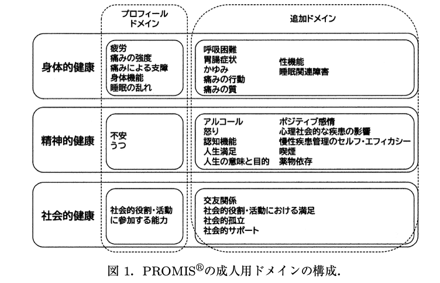

## PROMISの項目バンク作成

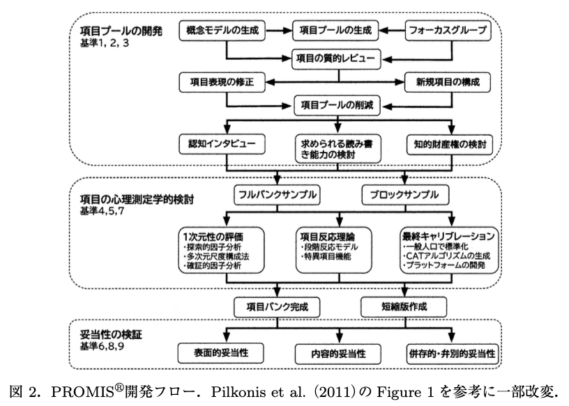

# Rによるチュートリアル

## R：用いるRパッケージ

- 以降では、以下のRパッケージを用いる。まずはltmパッケージのLSATというデモデータを用いる。
- irtoysパッケージがIRTに関する便利な関数を提供しており、推定はltmパッケージを使う

```r
library(psych)
library(irtoys)
library(ltm)
# LASTデータの読み込み
data(LSAT)
data <- LSAT
```

## R：データの確認

- LSATは、ロースクールの入学試験問題のデータであり、５問について1000名からデータをとっている。

```r
data
```

```
     Item 1 Item 2 Item 3 Item 4 Item 5
1         0      0      0      0      0
2         0      0      0      0      0
3         0      0      0      0      0
4         0      0      0      0      1
5         0      0      0      0      1
6         0      0      0      0      1
7         0      0      0      0      1
8         0      0      0      0      1
9         0      0      0      0      1
10        0      0      0      1      0
11        0      0      0      1      0
12        0      0      0      1      1
13        0      0      0      1      1
14        0      0      0      1      1
```

[output cut: 986 more lines]

## R：項目分析

- 古典的テスト理論の項目困難度（正答率）

```r
colMeans(data,na.rm = TRUE)
```

```
Item 1 Item 2 Item 3 Item 4 Item 5
 0.924  0.709  0.553  0.763  0.870
```

- 古典的テスト理論の識別力（I-T相関）

```r
cor(data, rowSums(data), use = "pairwise.complete.obs")
```

```
            [,1]
Item 1 0.3620104
Item 2 0.5667721
Item 3 0.6184398
Item 4 0.5344183
Item 5 0.4353664
```

## R：一次元性の確認

- 因子分析のスクリープロットで確認(理論上はテトラコリック相関が適切)

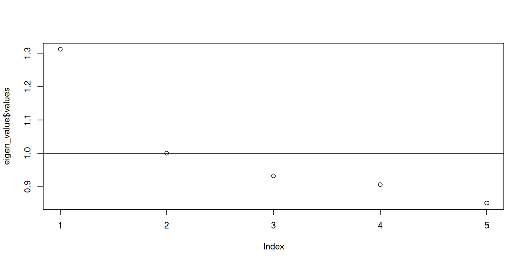

```r
eigen_value <- eigen(cor(data,use = "pairwise.complete.obs"))
plot(eigen_value$values)
abline(h=1)
```

## R：IRTのパラメータ推定

- 1PLMのパラメータ推定(結果のestの1列目は識別力（全項目共通）、2列目は困難度)

```r
result_1PLM <- est(data, model = "1PL", engine = "ltm")
result_1PLM$est
```

```
            [,1]       [,2] [,3]
Item 1 0.7551354 -3.6152642    0
Item 2 0.7551354 -1.3224200    0
Item 3 0.7551354 -0.3176311    0
Item 4 0.7551354 -1.7300895    0
Item 5 0.7551354 -2.7801707    0
```

## R：IRTのパラメータ推定

- 2PLMのパラメータ推定(結果のestの1列目は識別力、2列目は困難度)。以降2PLMを用いる。

```r
result_2PLM <- est(data, model = "2PL", engine = "ltm")
result_2PLM$est
```

```
            [,1]       [,2] [,3]
Item 1 0.8253717 -3.3597333    0
Item 2 0.7229498 -1.3696501    0
Item 3 0.8904752 -0.2798981    0
Item 4 0.6885500 -1.8659193    0
Item 5 0.6574511 -3.1235746    0
```

## R：特性値（能力）の推定

- mlebme関数で、特性値(能力)θを個人ごとに推定することができる。

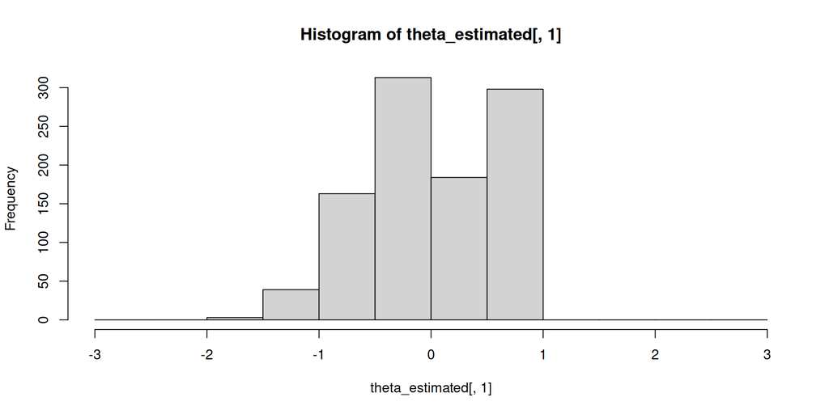

```r
theta_estimated <- mlebme(data, ip = result_2PLM$est, method = "BM")
hist(theta_estimated[,1],breaks=seq(-3,3,0.5))
```

## R：局所独立性の検討

- irf()関数を用いて正答確率を推定し、実際のデータとの残差得点を計算し(diff_correct)、残差得点間の相関を計算して$Q_{3}$統計量を出す(絶対値で0.2を越える場合は局所独立性を疑う)。

```r
prob_correct <- irf(ip = result_2PLM$est, x = theta_estimated[,1])
diff_correct <- data - prob_correct$f
Q3 <- cor(x = diff_correct, y = diff_correct, use = "pairwise.complete.obs")
Q3
```

```
            Item 1      Item 2      Item 3       Item 4       Item 5
Item 1  1.00000000 -0.04142824 -0.04101429 -0.064167975 -0.062538809
Item 2 -0.04142824  1.00000000 -0.11322248 -0.097060194 -0.029585197
Item 3 -0.04101429 -0.11322248  1.00000000 -0.092262203 -0.104216701
Item 4 -0.06416797 -0.09706019 -0.09226220  1.000000000 -0.003656669
Item 5 -0.06253881 -0.02958520 -0.10421670 -0.003656669  1.000000000
```

## R：適合度の検討

- itf()関数によって項目適合度を検討できる（項目１をチェック、有意になってないか、点と実線が乖離してないか）

```r
itf(data, item = 1, ip = result_2PLM$est, theta = theta_estimated[,1])
```

```
 Statistic         DF    P-value
10.0741811  6.0000000  0.1215627
```

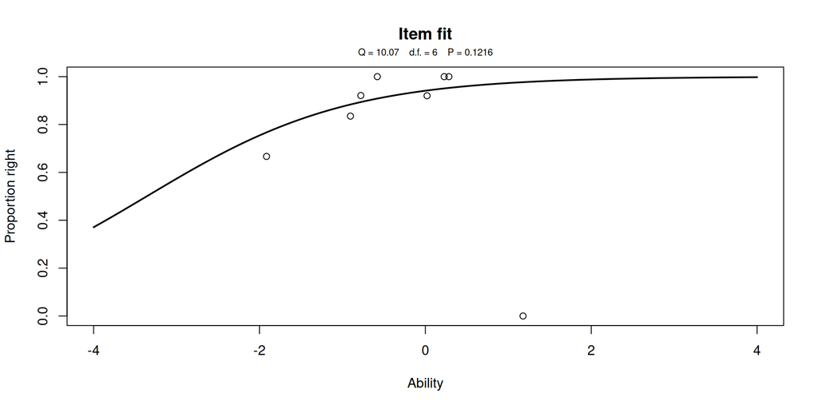

## R：項目特性曲線

- irf()関数を使ってICCを描くことができる。

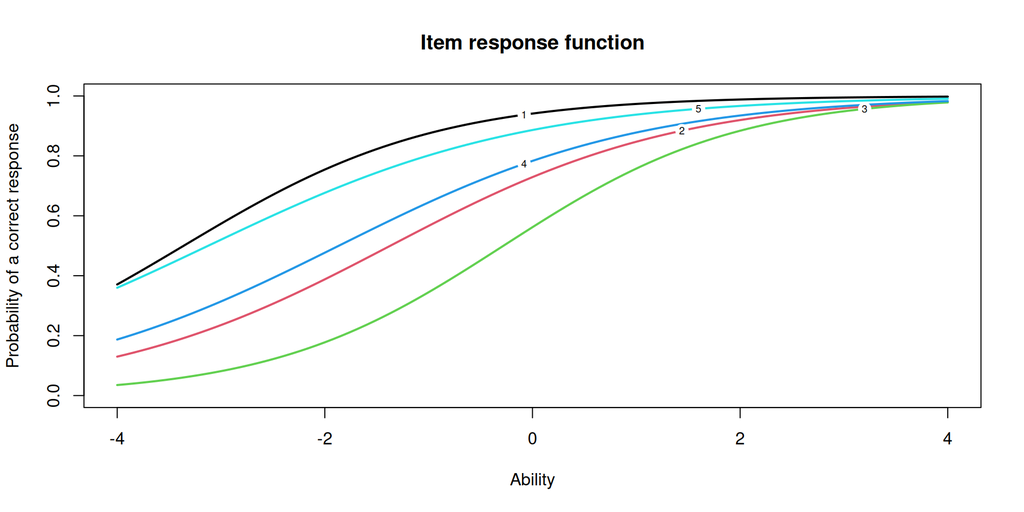

```r
plot(irf(ip = result_2PLM$est), co = NA, label = TRUE)
```

## R：テスト情報曲線

- tif()関数を使ってテスト情報曲線を描くことができる。

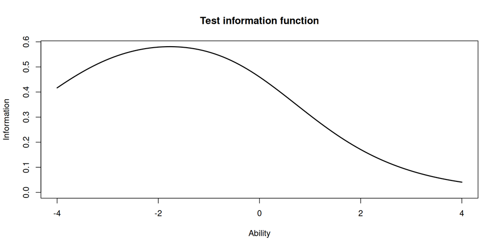

```r
plot(tif(ip = result_2PLM$est))
```

## R：IRTによる等化

- 等化をするにはRのplinkパッケージを用いる。plinkのデータを読み込んで、以降ではその中のKB04というデータを使う。
- KB04は*Test Equating, Scaling, and Linking*のデモデータ

```r
library(plink)
data(plink)
```

## R：推定されたパラメータの確認

- KB04には、parsというパラメータの情報を入れたリスト（form.xとform.yの２つがある）とcommonという共通項目の番号を記載したリストがある。
- まず、parsのform.xを確認する（3PLMの推定結果）。form.yでもう一方も確認できる。

```r
KB04$pars$form.x
```

```
   discrimination difficulty asymptote
1          0.5496    -1.7960    0.1751
2          0.7891    -0.4796    0.1165
3          0.4551    -0.7101    0.2087
4          1.4443     0.4833    0.2826
5          0.9740    -0.1680    0.2625
6          0.5839    -0.8567    0.2038
7          0.8604     0.4546    0.3224
8          1.1445    -0.1301    0.2209
9          0.7544     0.0212    0.1600
10         0.9170     1.0139    0.3648
11         0.9592     0.7218    0.2399
12         0.6633     0.0506    0.1240
13         1.2324     0.4167    0.2535
14         1.0492     0.7882    0.1569
```

[output cut: 22 more lines]

## R：共通項目の確認

- commonで共通項目の番号を確認する。common[,2]でform.yの共通項目も確認できる（このデータはどちらも同じ番号）。

```r
KB04$common[,1]
```

```
 [1]  3  6  9 12 15 18 21 24 27 30 33 36
```

## R：plinkパッケージによる等化

- plinkパッケージの使い方は少しややこしいが、以下の手順で行う。
1. as.irt.pars()関数でデータを準備
2. plink()関数で等化
3. link.pars()関数で等化した後のパラメータを得る

## R：等化するデータの準備

- as.irt.pars()関数でデータを準備をするが、as.irt.pars(x, common, cat, poly.mod)の引数を用意する。
- xは項目パラメタのリスト、commonは共通項目のデータ、catは各項目のカテゴリ数（２値なら２）、poly.modでは項目数と推定に用いたモデルを指定する。なお今回は、能力パラメタの等化はしてないが、必要ならば、ここで指定する。

```r
x <- list(KB04$pars$form.x, KB04$pars$form.y)
common <- data.frame(KB04$common[,1],KB04$common[,2])
cat <- list(rep(2,36),rep(2,36)) #2値が36項目
poly_mod <- list(as.poly.mod(36,model="drm"),as.poly.mod(36,model="drm")) #drmは2値IRT
irt_pars <- as.irt.pars(x, common, cat, poly_mod)
```

## R：plink関数による等化

- plink()関数の引数を設定して実行する。
- plink(x, common,rescale,base.grp)関数の引数は、xにas.irt.pars()で用意したオブジェクト、commonに共通項目のデータ,rescaleで等化法の指定（ただし等化は全ての手法で実行するので出力を指定している）、base.grpに基準集団の指定をする（今回はxが基準であり、１つ目のリストなので１）。

```r
result <- plink(irt_pars, common, rescale = "MM", base.grp=1)
summary(result)
```

```
-------  group2/group1*  -------
Linking Constants

                     A        B
Mean/Mean     0.821513 0.457711
Mean/Sigma    0.855511 0.441053
Haebara       0.907748 0.408260
Stocking-Lord 0.900655 0.425961
```

## R：等化した後のパラメータを得る

- link.pars()関数で等化後のパラメタを得る。なお、能力パラメタの等化もしている場合は、link.ability()で能力パラメタの等化後の値を得ることができる。

```r
link_result <- link.pars(result)
link_result
```

```
$group1
        [,1]    [,2]   [,3]
 [1,] 0.5496 -1.7960 0.1751
 [2,] 0.7891 -0.4796 0.1165
 [3,] 0.4551 -0.7101 0.2087
 [4,] 1.4443  0.4833 0.2826
 [5,] 0.9740 -0.1680 0.2625
 [6,] 0.5839 -0.8567 0.2038
 [7,] 0.8604  0.4546 0.3224
 [8,] 1.1445 -0.1301 0.2209
 [9,] 0.7544  0.0212 0.1600
[10,] 0.9170  1.0139 0.3648
[11,] 0.9592  0.7218 0.2399
[12,] 0.6633  0.0506 0.1240
[13,] 1.2324  0.4167 0.2535
```

[output cut: 62 more lines]

## R：等化の確認

- form.yの困難度パラメタの変化を確認する。等化によって移動しているのがわかる。

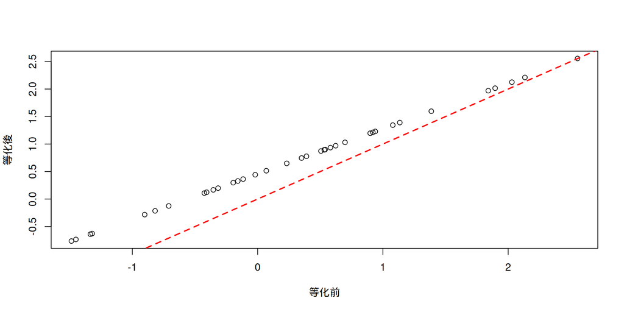

```r
plot(KB04$pars$form.y$difficulty,link_result$group2[,2],
    xlab = "等化前",ylab = "等化後")
abline(a = 0, b = 1, col = "red", lty = 2, lwd = 2)
```

## まとめ

- IRTはテストの効率的な運用を考えた場合にメリットが多い理論である。
- IRTには前提条件があるので、それを満たすのか検討する。
- 等化においてはデザインが重要なので、慎重に計画する。
- IRTの利用においてはRが便利なパッケージを用意している。

## 参考・引用文献

- 加藤健太郎・山田剛史・川端一光(2014). Rによる項目反応理論 オーム社
- 繁桝算男(編)(2023). 心理・教育・人事のためのテスト学入門 誠信書房
- 柴山直 (2012). 全国規模の学力調査における重複テスト分冊法の展開可能性について 平成２３年度文部科学省委託研究「学力調査を活用した専門的課題分析に関する調査研究」